# ProjectEx1_322794629_209190172

```python
!pip install findspark
!pip install pyspark
```

```
     |████████████████████████████████| 281.4 MB 47 kB/s
     |████████████████████████████████| 199 kB 47.3 MB/s
```

```python
### IMPORTS
from pyspark.sql import functions as f
from pyspark.sql.functions import *
from pyspark.sql import *
import findspark
from pyspark.sql.types import *
from pyspark.sql import SparkSession

from matplotlib import pyplot as plt
import inflect
```

```python
def init_spark(app_name: str):
  spark = SparkSession.builder.appName(app_name).getOrCreate()
  sc = spark.sparkContext
  return spark, sc

spark, sc = init_spark('demo')
```

# **1. Our Data Set**

We chose the data set "2016 Olympics in Rio de Janeiro"

The dataset contains personal and physical inforamtion of each athlete who paricipated in the olympics games in 2016, and their results (how many medals they won from each kind).

Dataset link: https://www.kaggle.com/datasets/rio2016/olympic-games

```python
data = spark.read.option("header", "true").csv("athletes.csv")
data.show()
```

```
+---------+--------------------+-----------+------+--------+------+------+------------+----+------+------+
|       id|                name|nationality|   sex|     dob|height|weight|       sport|gold|silver|bronze|
+---------+--------------------+-----------+------+--------+------+------+------------+----+------+------+
|736041664|      A Jesus Garcia|        ESP|  male|10/17/69|  1.72|    64|   athletics|   0|     0|     0|
|532037425|          A Lam Shin|        KOR|female| 9/23/86|  1.68|    56|     fencing|   0|     0|     0|
|435962603|         Aaron Brown|        CAN|  male| 5/27/92|  1.98|    79|   athletics|   0|     0|     1|
|521041435|          Aaron Cook|        MDA|  male|  1/2/91|  1.83|    80|   taekwondo|   0|     0|     0|
| 33922579|          Aaron Gate|        NZL|  male|11/26/90|  1.81|    71|     cycling|   0|     0|     0|
|173071782|         Aaron Royle|        AUS|  male| 1/26/90|   1.8|    67|   triathlon|   0|     0|     0|
|266237702|       Aaron Russell|        USA|  male|  6/4/93|  2.05|    98|  volleyball|   0|     0|     1|
|382571888|       Aaron Younger|        AUS|  male| 9/25/91|  1.93|   100|    aquatics|   0|     0|     0|
| 87689776| Aauri Lorena Bokesa|        ESP|female|12/14/88|   1.8|    62|   athletics|   0|     0|     0|
|997877719|     Ababel Yeshaneh|        ETH|female| 7/22/91|  1.65|    54|   athletics|   0|     0|     0|
|343694681|         Abadi Hadis|        ETH|  male| 11/6/97|   1.7|    63|   athletics|   0|     0|     0|
|591319906|Abbas Abubakar Abbas|        BRN|  male| 5/17/96|  1.75|    66|   athletics|   0|     0|     0|
|258556239|          Abbas Qali|        IOA|  male|10/11/92|  null|  null|    aquatics|   0|     0|     0|
|376068084|    Abbey D'Agostino|        USA|female| 5/25/92|  1.61|    49|   athletics|   0|     0|     0|
|162792594|      Abbey Weitzeil|        USA|female| 12/3/96|  1.78|    68|    aquatics|   1|     1|     0|
|521036704|         Abbie Brown|        GBR|female| 4/10/96|  1.76|    71|rugby sevens|   0|     0|     0|
|149397772|     Abbos Rakhmonov|        UZB|  male|  7/7/98|  1.61|    57|   wrestling|   0|     0|     0|
|256673338|    Abbubaker Mobara|        RSA|  male| 2/18/94|  1.75|    64|    football|   0|     0|     0|
|337369662|          Abby Erceg|        NZL|female|11/20/89|  1.75|    68|    football|   0|     0|     0|
|334169879|Abd Elhalim Moham...|        EGY|  male|  6/3/89|   2.1|    88|  volleyball|   0|     0|     0|
+---------+--------------------+-----------+------+--------+------+------+------------+----+------+------+
only showing top 20 rows
```

```python
# shows that the number of atheles who won more than one medal of the same kind is negligible.
data.groupBy("gold").count().orderBy('gold').show()
data.groupBy("silver").count().orderBy('silver').show()
data.groupBy("bronze").count().orderBy('bronze').show()
```

```
+----+-----+
|gold|count|
+----+-----+
|   0|10919|
|   1|  584|
|   2|   27|
|   3|    5|
|   4|    2|
|   5|    1|
+----+-----+

+------+-----+
|silver|count|
+------+-----+
|     0|10904|
|     1|  613|
|     2|   21|
+------+-----+

+------+-----+
|bronze|count|
+------+-----+
|     0|10845|
|     1|  682|
|     2|   11|
+------+-----+
```

## **Transformation**

We cleaned the dataset from invalid records and we added more informative columns.

### **Columns gold, silver, bronze:**

We noticed that the number of medals won of each type (gold, silver, bronze) is mostly 0 or 1 (as shown in the dataframes above).

We extracted the main and important information from those columns, by adding columns of:

1. total medals won
2. if the athlete won any medals
3. if the athlete won any gold medals

(Even though column 2 indicates if the athlete won any medals, we decided to add column 3 because it represents an even greater achievement)

Therefore, we decided to drop the columns: gold, silver, bronze.

### **Columns sex, dob:**

We transformed these columns into the columns 'male' and 'age' respectively. Under these columns, the values are more informative and easy to use.

### **Columns id, name:**

We also decided to drop the columns: id, name, because they don't contribute any valuable information.

```python
# functions to create the new columns
def won_medal(gold, silver, bronze):
  if int(gold) or int(silver) or int(bronze):
    return 1
  return 0

def won_gold(gold):
  if int(gold):
    return 1
  return 0

def total_medals(gold, silver, bronze):
  return int(gold) + int(silver) + int(bronze)

def get_age(dob):

  olympic_date = [8, 5, 2016]
  dob = [int(x) for x in dob.split('/')]

  if dob[2] <= 5:
    dob[2] += 2000

  else:
    dob[2] += 1900

  return olympic_date[2] - dob[2] - ((olympic_date[0], olympic_date[1]) < (dob[0], dob[1]))

def get_is_male(sex):
  if sex == 'male':
    return 1
  return 0

def convert_height(height):
  return int(100 * float(height))

def convert_weight(weight):
  return int(weight)

# turn functions into udfs
won_medal_udf = f.udf(won_medal, IntegerType())
won_gold_udf = f.udf(won_gold, IntegerType())
total_medals_udf = f.udf(total_medals, IntegerType())
get_age_udf = f.udf(get_age, IntegerType())
get_is_male_udf = f.udf(get_is_male, IntegerType())
convert_height_udf = f.udf(convert_height, IntegerType())
convert_weight_udf = f.udf(convert_weight, IntegerType())
```

### **Missing Values (Null)**

We noticed that there are records with missing information in some columns. We would want to see how many missing values there are for every column, and remove records with missing information.

```python
def count_missing_values(data, col_name):
  """Gets a dataframe 'data' and string 'col_name' and prints the number
  of missing values the column 'col_name' has."""
  count_original = data.count()
  count_valid = data.filter(col(col_name).cast('string') != 'null').count()
  null_num = count_original - count_valid
  print(f"For column '{col_name}',{' '*(12-len(col_name))}there are {null_num} null values.")

print("Different Columns and Their Missing Values Count:")
print()
for col_name in data.columns:
  count_missing_values(data, col_name)
```

```
Different Columns and Their Missing Values Count:

For column 'id',          there are 0 null values.
For column 'name',        there are 0 null values.
For column 'nationality', there are 0 null values.
For column 'sex',         there are 0 null values.
For column 'dob',         there are 1 null values.
For column 'height',      there are 330 null values.
For column 'weight',      there are 659 null values.
For column 'sport',       there are 0 null values.
For column 'gold',        there are 0 null values.
For column 'silver',      there are 0 null values.
For column 'bronze',      there are 0 null values.
```

We can see that only columns 'height', 'weight' and 'dob' have missing values. So, we will remove all of them.

To be clear, **our final data set will not contain any records with missing values (nulls).**

```python
original_count = data.count()
print(f"Original number of records: {original_count}")

# clean invalid records
data = data.filter(col('height') != 'null') \
           .filter(col('weight') != 'null') \
           .filter(col('dob') != 'null')

current_count = data.count()
print(f"Number of records after removing nulls: {current_count}")
print(f"(meaning we removed a total of {original_count - current_count} records)")
```

```
Original number of records: 11538
Number of records after removing nulls: 10858
(meaning we removed a total of 680 records)
```

**We are left with 10,858 records in our data set.**

Below, we will add new columns to our data set - but those columns will be well-defined transformations of existing columns, therefore **will not contain missing values** (because we already removed nulls from the existing columns).

Explicitly, the number of missing values for columns: 'age', 'male', 'won_any', 'won_gold', 'total_medals' **is 0**.

```python
# add new infomrative columns
data = data.withColumn("won_any", won_medal_udf(col("gold"), col("silver"), col("bronze"))) \
           .withColumn("won_gold", won_gold_udf(col("gold"))) \
           .withColumn("total_medals", total_medals_udf(col("gold"), col("silver"), col("bronze"))) \
           .withColumn("age", get_age_udf(col("dob"))) \
           .withColumn("male", get_is_male_udf("sex")) \
           .withColumn("height", convert_height_udf("height")) \
           .withColumn("weight", convert_weight_udf("weight"))

# choose the columns we want and rearrange them in our desirable order
data = data.select(['nationality', 'sport', 'age', 'male', 'height', 'weight', 'won_any', 'won_gold', 'total_medals'])
```

```python
# our final (clean and transformed) data set
data.show()
```

```
+-----------+------------+---+----+------+------+-------+--------+------------+
|nationality|       sport|age|male|height|weight|won_any|won_gold|total_medals|
+-----------+------------+---+----+------+------+-------+--------+------------+
|        ESP|   athletics| 46|   1|   172|    64|      0|       0|           0|
|        KOR|     fencing| 29|   0|   168|    56|      0|       0|           0|
|        CAN|   athletics| 24|   1|   198|    79|      1|       0|           1|
|        MDA|   taekwondo| 25|   1|   183|    80|      0|       0|           0|
|        NZL|     cycling| 25|   1|   181|    71|      0|       0|           0|
|        AUS|   triathlon| 26|   1|   180|    67|      0|       0|           0|
|        USA|  volleyball| 23|   1|   204|    98|      1|       0|           1|
|        AUS|    aquatics| 24|   1|   193|   100|      0|       0|           0|
|        ESP|   athletics| 27|   0|   180|    62|      0|       0|           0|
|        ETH|   athletics| 25|   0|   165|    54|      0|       0|           0|
|        ETH|   athletics| 18|   1|   170|    63|      0|       0|           0|
|        BRN|   athletics| 20|   1|   175|    66|      0|       0|           0|
|        USA|   athletics| 24|   0|   161|    49|      0|       0|           0|
|        USA|    aquatics| 19|   0|   178|    68|      1|       1|           2|
|        GBR|rugby sevens| 20|   0|   176|    71|      0|       0|           0|
|        UZB|   wrestling| 18|   1|   161|    57|      0|       0|           0|
|        RSA|    football| 22|   1|   175|    64|      0|       0|           0|
|        NZL|    football| 26|   0|   175|    68|      0|       0|           0|
|        EGY|  volleyball| 27|   1|   210|    88|      0|       0|           0|
|        MAR|   athletics| 29|   1|   173|    57|      0|       0|           0|
+-----------+------------+---+----+------+------+-------+--------+------------+
only showing top 20 rows
```

### **Our data set meets the assignment requirements:**

- There are at least two numarical features: height, weight.
- There are at least two binary features: male, won_any.
- There are more then 4000 records (10858).
- All the columns' names are intuitive and easy to understand.

```python
# set style for all the graphs we will show.
plt.style.use('ggplot')

def statistical_desc(data, filterd_data, col_name, bin_num, units=None, xticks=None):
  """
  Gets a dataframe, the filtered dataframe, a column name, and shows
  statistics about the data, as well as plot a histogram of the filtered data
  with 'bin_num' bins, and units for the x values if necessary.
  """
  print("Statistical Description")
  data.describe(col_name).show()

  col_values = [x[0] for x in filterd_data.select(col_name).collect()]

  plt.title(f"Distribution of Different {col_name.title()} Values")
  plt.ylabel("athletes count")

  if units is not None:
    col_name += f" ({units})"

  if xticks is not None:
    plt.xticks(xticks)

  plt.xlabel(col_name)

  plt.hist(col_values, bins=bin_num, edgecolor='black', linewidth=1, color="cornflowerblue")

  plt.show()
```

Now, we will summarize the relevant information about each of our columns - numerical columns, and then categorical columns.

# **2. Initial Analysis of Our Data Set**

## Age Column:

As shown below under the statistical description, the min age is 13 and the max age is 62.

Although 13 seems quit young, upon re-searching online we found out that according to the offical Olympic website, there's no age limit for taking part in the Olympic Games.

Regarding age 62, we found that the top 5 oldest atheletes participates in equestrian (horse riding), which is a less physical deminding sport.

Therefore, we can conclude that all the values under this column are valid.

According to the "minimal ink-paper ratio" principal, we chose to remove all values greater than 45 while displaying the graph (the distribution is clear and displaying the entire long tail is unnecessary).

*link to the offical Olympic Games website:

https://olympics.com/ioc/faq/competing-and-being-part-of-the-games#:~:text=What%20is%20the%20age%20limit,part%20in%20the%20Olympic%20Games.

```
Statistical Description
+-------+-----------------+
|summary|              age|
+-------+-----------------+
|  count|            10858|
|   mean| 26.4237428624056|
| stddev|5.396171440422407|
|    min|               13|
|    max|               62|
+-------+-----------------+
```

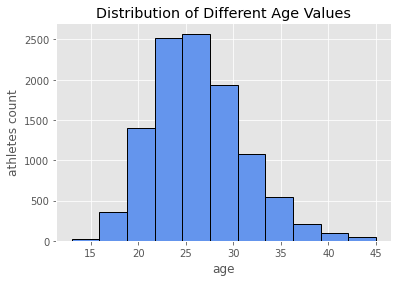

```python
# remove extreme values
temp1 = data.filter(col('age') <= 45)

statistical_desc(data, temp1, 'age', bin_num=11)
```

## Weight Column:

As shown below under the statistical description, the min weight is 31 and the max weight is 170.

Since the Olympic Games includes high varity of sports and we already know the age range, we can conclude that all the values under this cloumn are valid.

Again, according to the "minimal ink-paper ratio" principal we chose to keep only the values between 40 and 135 in our graph, for the same reason mentioned in the 'Age Column' description.

```
Statistical Description
+-------+-----------------+
|summary|           weight|
+-------+-----------------+
|  count|            10858|
|   mean| 72.0709154540431|
| stddev|16.16235839174805|
|    min|               31|
|    max|              170|
+-------+-----------------+
```

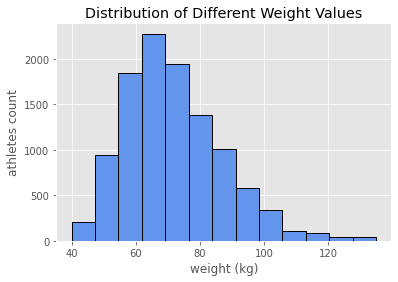

```python
# remove extreme values
temp2 = data.filter("weight between 40 and 135")

statistical_desc(data, temp2, 'weight', bin_num=13, units='kg')
```

## Height Column:

As shown below under the statistical description, the min height is 121 and the max height is 221.

Since the Olympic Games includes high varity of sports and we already know the age range, we can conclude that all the values under this cloumn are valid.

According to the "minimal ink-paper ratio" we chose to keep only the values between 140 and 210 in our graph, for the same reason mentioned in the 'Age Column' description.

```
Statistical Description
+-------+------------------+
|summary|            height|
+-------+------------------+
|  count|             10858|
|   mean|176.68511696445017|
| stddev|11.290059886188173|
|    min|               121|
|    max|               221|
+-------+------------------+
```

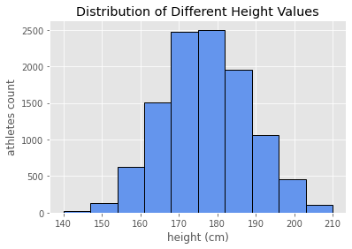

```python
# remove extreme values
temp3 = data.filter("height between 140 and 210")

statistical_desc(data, temp3, 'height', bin_num=10, units='cm')
```

## Total_Medals Column:

We decieded to keep only the values greater than 0, since the majority of the athletes in the Olympic Games didn't win any medals. That way we can see the distribution of this column more clearly.

Moreover, according to the "minimal ink-paper ratio" we chose to keep only the values smaller then 6 in our graph, for the same reason mentioned in the 'Age Column' description.

```
Statistical Description
+-------+-------------------+
|summary|       total_medals|
+-------+-------------------+
|  count|              10858|
|   mean| 0.1768281451464358|
| stddev|0.43224652697597177|
|    min|                  0|
|    max|                  6|
+-------+-------------------+
```

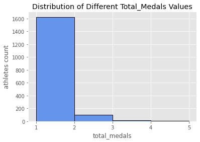

```python
# remove extreme values
temp4 = data.filter("total_medals between 1 and 5")

statistical_desc(data, temp4, 'total_medals', bin_num=4, xticks=[1, 2, 3, 4 ,5])
```

```python
def create_pie_chart_binary_feature(data, col_name, title):
  """
  Gets a dataframe, column and title, and plots a pie chart displaying
  the amount of each unique value in the column of the data.
  """
  lst = data.groupBy(col_name).count().collect()
  labels = [x[0] for x in lst]
  count = [x[1] for x in lst]

  plt.pie(count, labels=labels, autopct='%1.2f%%', startangle=90,
          wedgeprops={'edgecolor':'black'})
  plt.title(title)

  plt.show()
```

## Male Column:

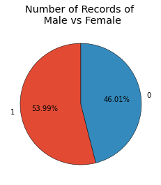

```python
title = "Number of Records of \n Male vs Female"
create_pie_chart_binary_feature(data, 'male', title)
```

## Won_medal Column:

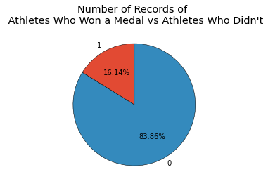

```python
title = "Number of Records of \n Athletes Who Won a Medal vs Athletes Who Didn't"
create_pie_chart_binary_feature(data, 'won_any', title)
```

## Won_gold Column:

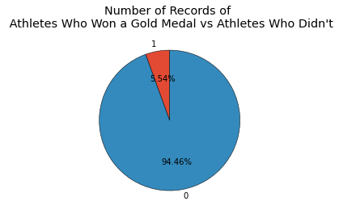

```python
title = "Number of Records of \n Athletes Who Won a Gold Medal vs Athletes Who Didn't"
create_pie_chart_binary_feature(data, 'won_gold', title)
```

```python
def create_horizontal_bar_plot_categorical_feature(data, col_name, figsize_tuple):
  lst = data.groupBy(col_name).count().orderBy(col('count')).collect()

  values = [x[0] for x in lst]
  count = [x[1] for x in lst]

  # for changing the col_name noun into plural
  engine = inflect.engine()

  plt.figure(figsize=figsize_tuple)
  plt.barh(values, count, color="cornflowerblue")
  plt.title(f"Distribution of Different {engine.plural(col_name).capitalize()} Across All Athletes")
  plt.xlabel("athletes count")
  plt.ylabel(col_name)
```

## Sport Column:

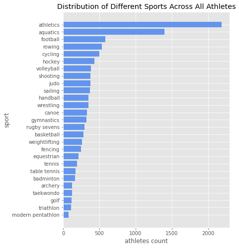

```python
create_horizontal_bar_plot_categorical_feature(data, 'sport', figsize_tuple=(6,8))
```

## Nationality Column:

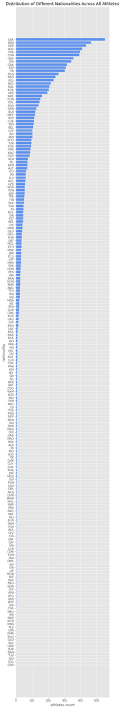

```python
create_horizontal_bar_plot_categorical_feature(data, 'nationality', figsize_tuple=(6,45))
```

# **3. Research Questions**

**First question type:**

- Among the athletes who won a medal, does increase in the athlete's height cause the number of medals won to increase?
- Among the athletes who won a medal, does increase in the athlete's weight cause the number of medals won to decrease?

**Second question type:**

- Does increase in the athlete's weight lead to an increase in the probabilty to win a medal?
- Among the athletes who participate in wrestling, does decrease in the athlete's weight lead to a decrease in the probabilty to win a medal?
- Among the athletes who participate in athletics, does decrease in the athlete's height lead to an increase in the probabilty to win a medal?

**Third question type:**

- Does the average height of the athletes change between the athletes who won a medal and the ones who didn't?
- Does the average weight of the athletes change between the athletes who won a medal and the ones who didn't?
- Does the average height of the athletes change between the different sport fields?